# AS3-2: 股市動態

第 6 組

2019-03-11 15:51:47

第 0 組

2019-03-09 13:11:11

組員： `B035040052 林榮鏵` `B056090039 楊禾馨` `M064020056閻俞蓉` `M064111003 洪筱涵` `M074111035 劉志峰`

**股票動態**

股票市場是買賣雙方交易公司股票的地方，也是個人和公司投資的最受歡迎的方式之一。現在估計世界股票市場規模達到數兆。紐約證券交易所位於紐約市，是世界上最大的股票市場。 紐約證券交易所約有2,800家上市公司。在這個問題上，我們將看看其中五家公司的每月股價：IB、通用電氣（GE）、寶潔、可口可樂和波音。此問題中使用的數據來自Infochimps。

使用`read.csv()`下載並讀取以下文件：

- `data/IBMStock.csv`
- `data/GEStock.csv`
- `data/ProcterGambleStock.csv`
- `data/CocaColaStock.csv`
- `data/BoeingStock.csv`

分別存入資料框`IBM`、`GE`、`ProcterGamble`、`CocaCola`和`Boeing`， 每個資料框都有兩個變量，描述如下：

- `Date`：日期
- `StockPrice`：給定月份公司的平均股價

在這個案例，我們將看看這些公司的股票動態如何隨著時間的推移而發生變化。

### Section-1 Summary Statistics

**§ 1.1** Our five datasets all have the same number of observations. How many observations are there in each data set?

```r
#讀取五個檔案
IBM=read.csv("data/IBMStock.csv")
GE=read.csv("data/GEStock.csv")
ProcterGamble=read.csv("data/ProcterGambleStock.csv")
CocaCola=read.csv("data/CocaColaStock.csv")
Boeing=read.csv("data/BoeingStock.csv")
#計算number of row
nrow(IBM)
```

```
[1] 480
```

480 observations

**§ 1.2** What is the earliest year in our datasets?

```r
#先將Date欄位屬性從factor轉成date
IBM$Date = as.Date(IBM$Date, "%m/%d/%y")
GE$Date = as.Date(GE$Date, "%m/%d/%y")
CocaCola$Date = as.Date(CocaCola$Date, "%m/%d/%y")
ProcterGamble$Date = as.Date(ProcterGamble$Date, "%m/%d/%y")
Boeing$Date = as.Date(Boeing$Date, "%m/%d/%y")
#找出最早的年份
IBM$Date[which.min(IBM$Date)]
```

```
[1] "1970-01-01"
```

```r
#另一種寫法
min(IBM$Date)
```

```r
IBM=read.csv('data/IBMStock.csv')
GE=read.csv('data/GEStock.csv')
ProcterGamble=read.csv('data/ProcterGambleStock.csv')
CocaCola=read.csv('data/CocaColaStock.csv')
Boeing=read.csv('data/BoeingStock.csv')

IBM$Date=as.Date(IBM$Date,"%m/%d/%y")
GE$Date=as.Date(GE$Date,"%m/%d/%y")
ProcterGamble$Date=as.Date(ProcterGamble$Date,"%m/%d/%y")
CocaCola$Date=as.Date(CocaCola$Date,"%m/%d/%y")
Boeing$Date=as.Date(Boeing$Date,"%m/%d/%y")
#
#
```

**§ 1.2** What is the earliest year in our datasets?

```r
IBM$Date[which.min(IBM$Date)]
```

```
[1] "1970-01-01"
```

```r
min(IBM$Date)#也是可以
```

```
[1] "1970-01-01"
```

```r
#
#
```

**§ 1.3** What is the latest year in our datasets?

```r
#找出最晚的年份
IBM$Date[which.max(IBM$Date)]
```

```r
max(IBM$Date)
```

```
[1] "2009-12-01"
```

```r
#
#
```

**§ 1.4** What is the mean stock price of IBM over this time period?

```r
#IBM的平均股價
mean(IBM$StockPrice) #144.4
```

```r
mean(IBM$StockPrice)
```

```
[1] 144.4
```

```r
#
#
```

**§ 1.5** What is the minimum stock price of General Electric (GE) over this time period?

```r
#GE的股價最小值
min(GE$StockPrice) #9.294
```

```r
min(GE$StockPrice)
```

```
[1] 9.294
```

```r
#
#
```

**§ 1.6** What is the maximum stock price of Coca-Cola over this time period?

```r
#Coca Cola的股價最大值
max(CocaCola$StockPrice) #146.6
```

```r
max(CocaCola$StockPrice)
```

```
[1] 146.6
```

```r
#
#
```

**§ 1.7** What is the median stock price of Boeing over this time period?

```r
#Boeing的股價中位數
median(Boeing$StockPrice) #44.88
```

```r
median(Boeing$StockPrice)
```

```
[1] 44.88
```

```r
#
#
```

**§ 1.8** What is the standard deviation of the stock price of Procter & Gamble over this time period?

```r
#Procter & Gamble的股價標準差
sd(ProcterGamble$StockPrice) #18.19
```

```r
sd(ProcterGamble$StockPrice)
```

```
[1] 18.19
```

```r
#
#
```

### Section-2 Visualizing Stock Dynamics

**§ 2.1** Around what year did Coca-Cola has its highest stock price in this time period? Around what year did Coca-Cola has its lowest stock price in this time period?

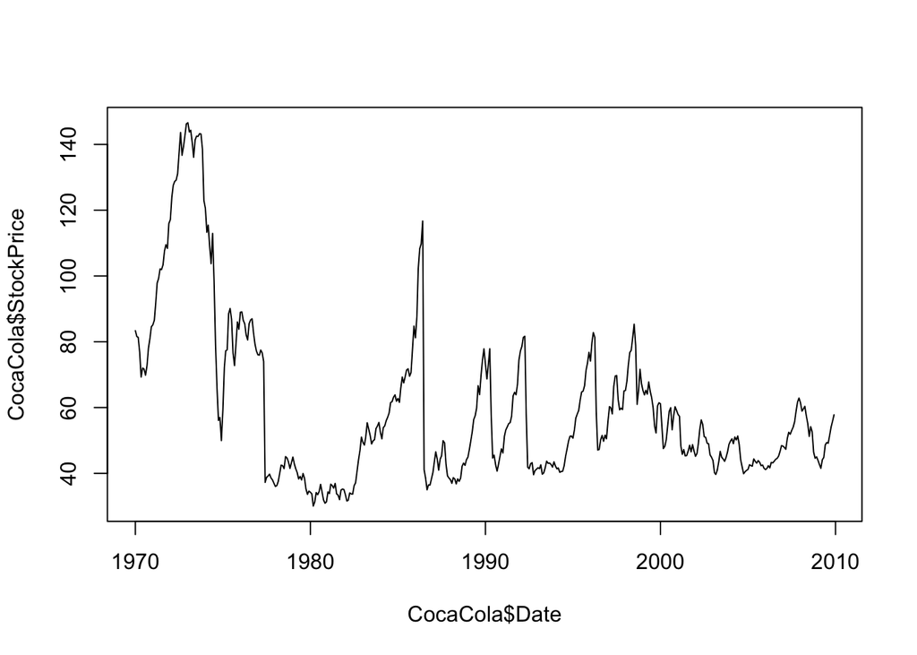

```r
#X軸為年份，y軸為股價
plot(CocaCola$Date,CocaCola$StockPrice,type="l")
```

highest year: 1973, lowest year: 1980

**§ 2.2** In March of 2000, the technology bubble burst, and a stock market crash occurred. According to this plot, which company’s stock dropped more?

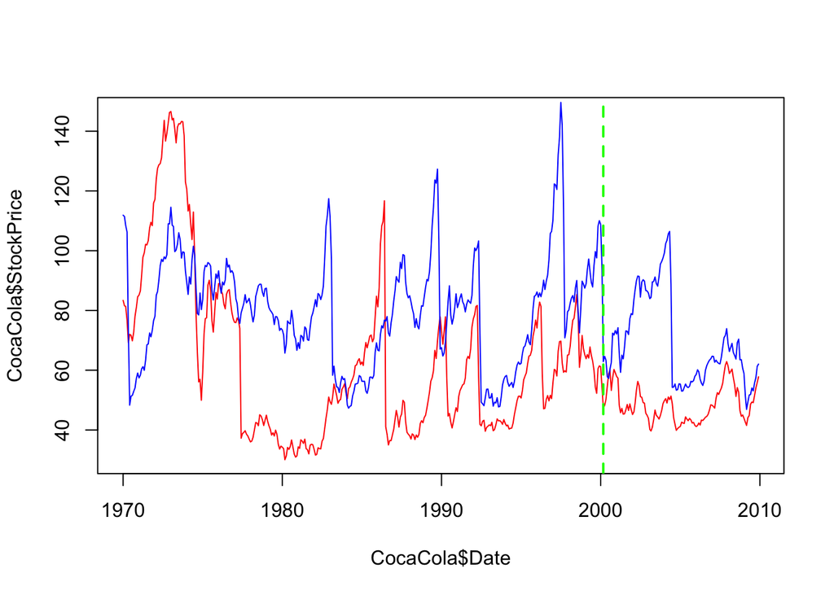

```r
#Coca cola為紅色線
plot(CocaCola$Date,CocaCola$StockPrice,type="l",col="red")
#Procter & Gamble為藍色線
lines(ProcterGamble$Date, ProcterGamble$StockPrice,col="blue")
#在2000年三月加一條綠色虛線
abline(v=as.Date(c("2000-03-01")), lwd=2, lty=2, col="green")
```

ProcterGamble (藍色線) dropped more.

**§ 2.3** (a) Around 1983, the stock for one of these companies (Coca-Cola or Procter and Gamble) was going up, while the other was going down. Which one was going up?

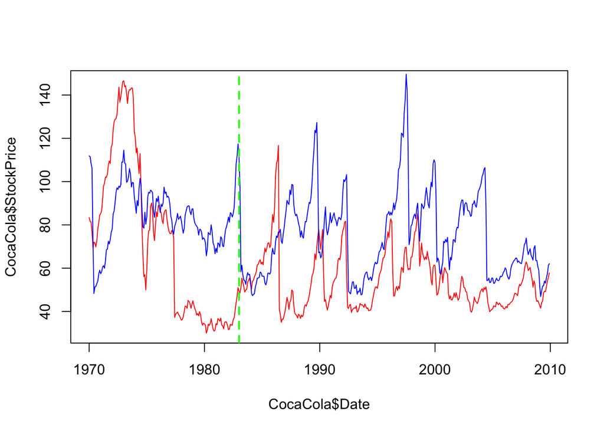

```r
#Coca cola為紅色線
plot(CocaCola$Date,CocaCola$StockPrice,type="l",col="red")
#Procter & Gamble為藍色線
lines(ProcterGamble$Date, ProcterGamble$StockPrice,col="blue")
#在1983年加一條綠色虛線
abline(v=as.Date(c("1983-01-01")), lwd=2, lty=2,col="green")
```

Coca Cola (紅色線) 的股價上升

2. In the time period shown in the plot, which stock generally has lower values?

```r
# same as the plot above
```

Coca-Cola has lower values

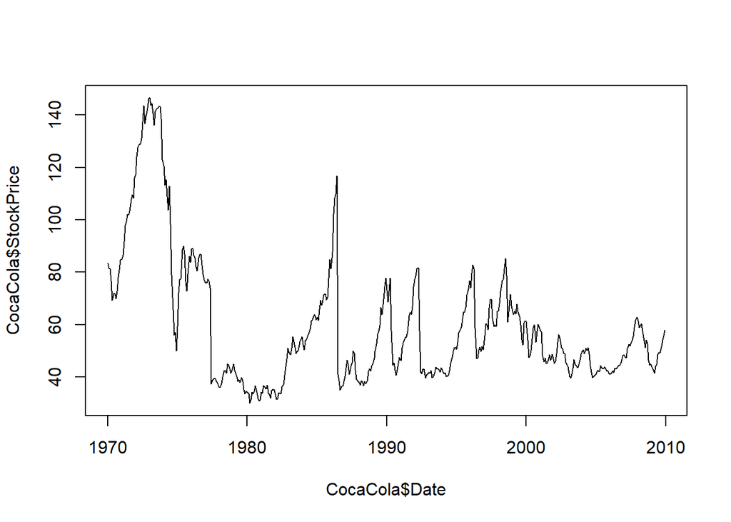

```r
plot(CocaCola$Date,CocaCola$StockPrice,type="l")
```

```r
#
#
```

**§ 2.2** In March of 2000, the technology bubble burst, and a stock market crash occurred. According to this plot, which company’s stock dropped more?

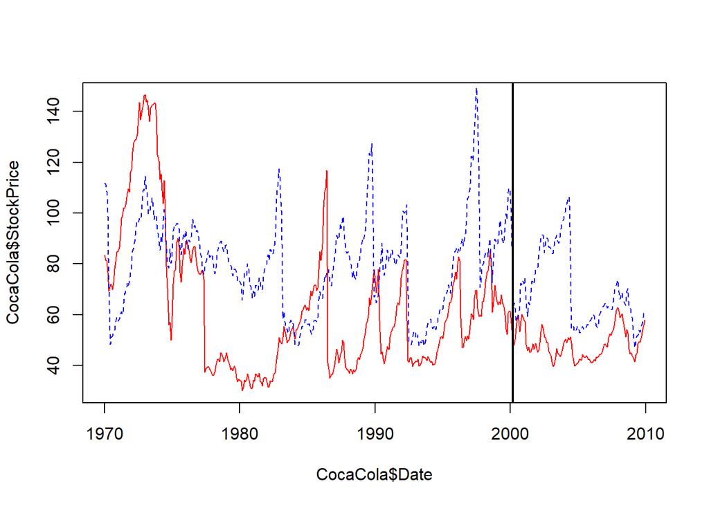

```r
plot(CocaCola$Date,CocaCola$StockPrice,type="l",col="red")
lines(ProcterGamble$Date,ProcterGamble$StockPrice,col="blue",lty=2)
abline(v=as.Date(c("2000-03-01")),lwd=2)
```

```r
#
#
```

**§ 2.3** (a) Around 1983, the stock for one of these companies (Coca-Cola or Procter and Gamble) was going up, while the other was going down. Which one was going up?

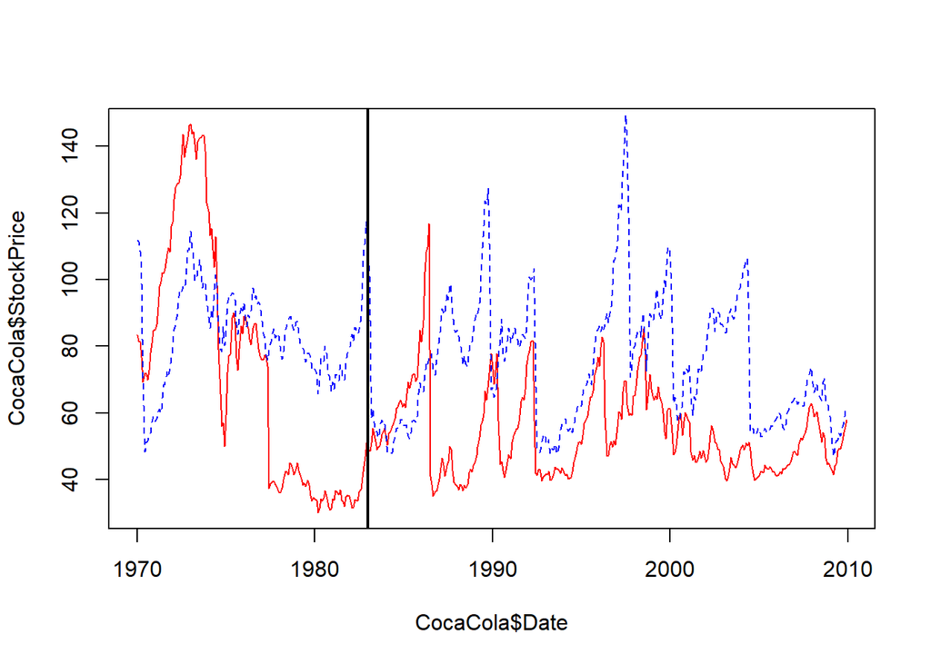

```r
plot(CocaCola$Date,CocaCola$StockPrice,type="l",col="red")
lines(ProcterGamble$Date,ProcterGamble$StockPrice,col="blue",lty=2)
abline(v=as.Date(c("1983-01-01")),lwd=2)
```

```r
#程式碼 下 zoom
#
```

2. In the time period shown in the plot, which stock generally has lower values?

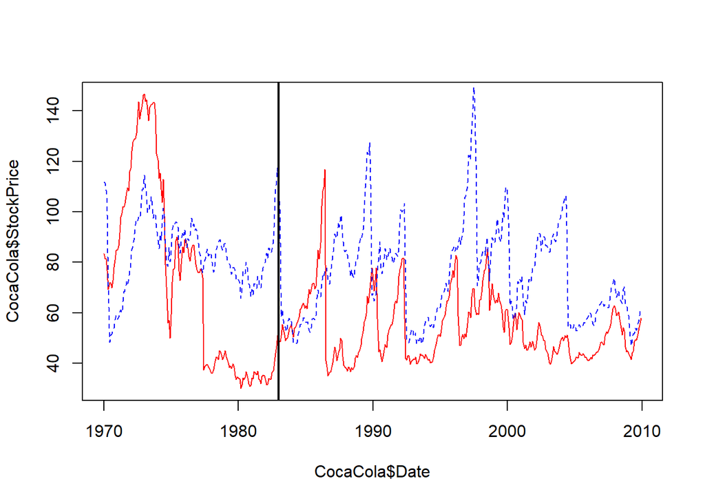

```r
plot(CocaCola$Date,CocaCola$StockPrice,type="l",col="red")
lines(ProcterGamble$Date,ProcterGamble$StockPrice,col="blue",lty=2)
abline(v=as.Date(c("1983-01-01")),lwd=2)
```

```r
#cocacola red point
#
```

### Section-3 Visualizing Stock Dynamics 1995-2005

**§ 3.1** Which stock fell the most right after the technology bubble burst in March 2000?

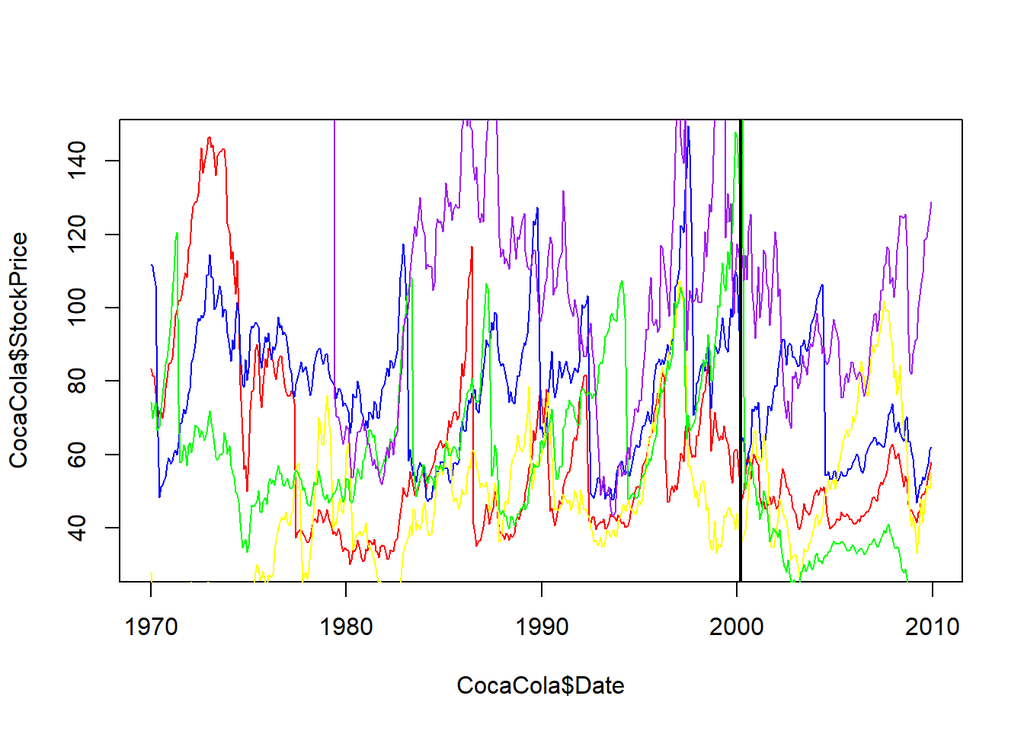

```r
plot(CocaCola$Date,CocaCola$StockPrice,type="l",col="red")
lines(ProcterGamble$Date,ProcterGamble$StockPrice,col="blue",lty=1)
lines(Boeing$Date,Boeing$StockPrice,col="yellow",lty=1)
lines(GE$Date,GE$StockPrice,col="green",lty=1)
lines(IBM$Date,IBM$StockPrice,col="purple",lty=1)
abline(v=as.Date(c("2000-03-01")),lwd=2)
```

```r
#
#
```

**§ 3.2** Which stock reaches the highest value in the time period 1995-2005?

```r
which(CocaCola$Date=="1995-01-01")
```

```
[1] 301
```

```r
which(CocaCola$Date=="2005-12-01")
```

```
[1] 432
```

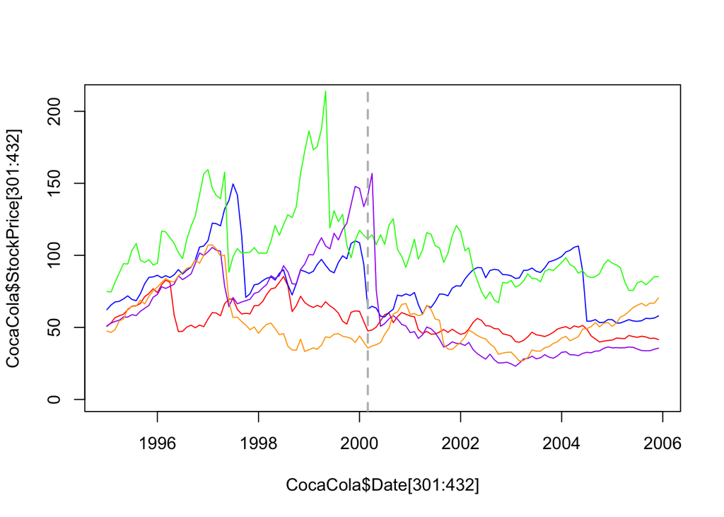

```r
plot(CocaCola$Date[301:432], CocaCola$StockPrice[301:432], type="l", col="red", ylim=c(0,210))
lines(ProcterGamble$Date[301:432], ProcterGamble$StockPrice[301:432],col="blue", ylim=c(0,210))
lines(IBM$Date[301:432], IBM$StockPrice[301:432],col="green", ylim=c(0,210))
lines(GE$Date[301:432], GE$StockPrice[301:432],col="purple", ylim=c(0,210))
lines(Boeing$Date[301:432], Boeing$StockPrice[301:432],col="orange", ylim=c(0,210))
#在2000年三月加上一條灰色虛線
abline(v=as.Date(c("2000-03-01")), lwd=2, col="gray",lty=2)
```

```r
#GE:pruple
#col = "red", "blue", "green", "purple", "orange", and "black"
#lty = 2:dashed, 3:dotted, 4:alternate between dashes and dots, 5:long-dashed
```

GE fell the most.

**§ 3.2** Which stock reaches the highest value in the time period 1995-2005?

```r
# see the graph above
#green:IBM
```

IBM reaches the highest value.

**§ 3.3** In October of 1997, there was a global stock market crash that was caused by an economic crisis in Asia. Comparing September 1997 to November 1997, which companies saw a decreasing trend in their stock price? (Select all that apply.)

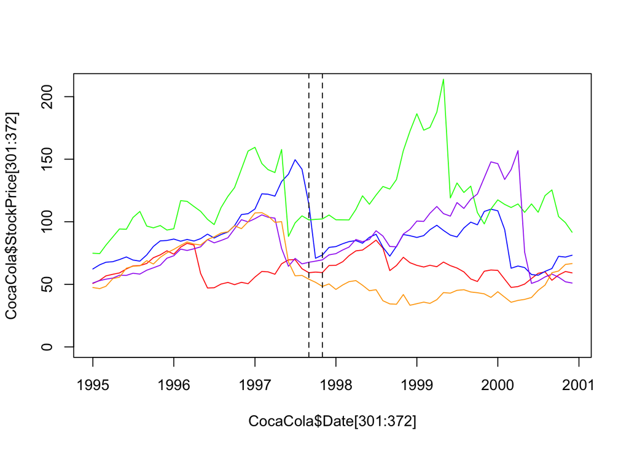

```r
plot(CocaCola$Date[301:372], CocaCola$StockPrice[301:372], type="l", col="red", ylim=c(0,210))
lines(ProcterGamble$Date[301:372], ProcterGamble$StockPrice[301:372],col="blue", ylim=c(0,210))
lines(IBM$Date[301:372], IBM$StockPrice[301:372],col="green", ylim=c(0,210))
lines(GE$Date[301:372], GE$StockPrice[301:372],col="purple", ylim=c(0,210))
lines(Boeing$Date[301:372], Boeing$StockPrice[301:372],col="orange", ylim=c(0,210))
#在1997九月到1997十一月加上虛線
abline(v=as.Date(c("1997-09-01")), lwd=1, lty=2)
abline(v=as.Date(c("1997-11-01")), lwd=1, lty=2)
```

```r
# blue:ProcterGamble, orange:Boeing
```

ProcterGamble and Boeing decreased trend in their stock price.

**§ 3.4** In the last two years of this time period (2004 and 2005) which stock seems to be performing the best, in terms of increasing stock price?

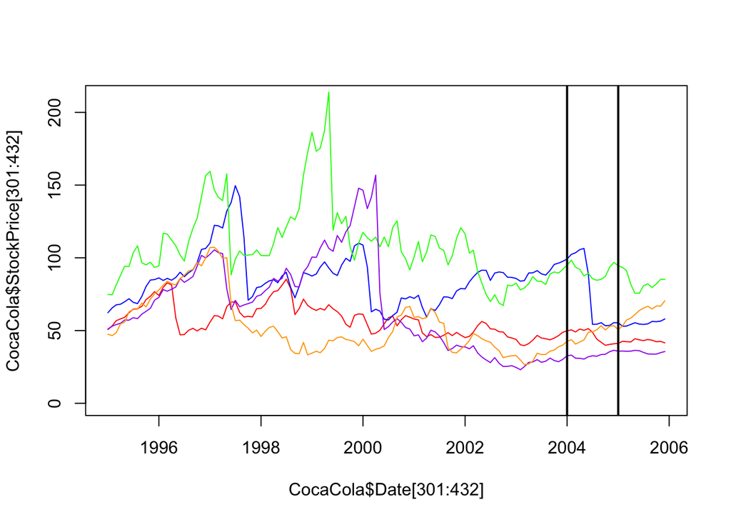

```r
plot(CocaCola$Date[301:432], CocaCola$StockPrice[301:432], type="l", col="red", ylim=c(0,210))
lines(ProcterGamble$Date[301:432], ProcterGamble$StockPrice[301:432],col="blue", ylim=c(0,210))
lines(IBM$Date[301:432], IBM$StockPrice[301:432],col="green", ylim=c(0,210))
lines(GE$Date[301:432], GE$StockPrice[301:432],col="purple", ylim=c(0,210))
lines(Boeing$Date[301:432], Boeing$StockPrice[301:432],col="orange", ylim=c(0,210))
##在2004年和2005年加上線
abline(v=as.Date(c("2004-01-01")), lwd=2)
abline(v=as.Date(c("2005-01-01")), lwd=2)
```

```r
#orange:Boeing
```

Boeing increased stock price.

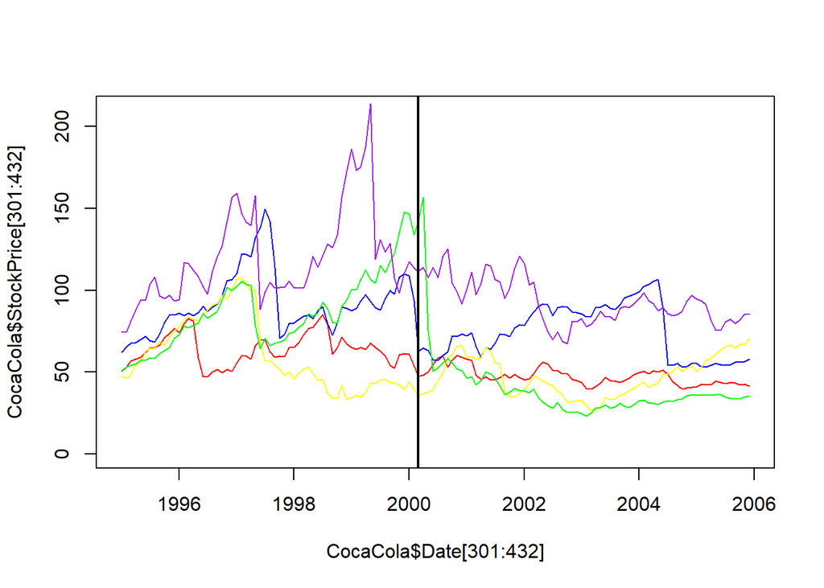

```r
plot(CocaCola$Date[301:432],CocaCola$StockPrice[301:432],type="l",col="red",ylim = c(0,210))
lines(ProcterGamble$Date[301:432],ProcterGamble$StockPrice[301:432],col="blue",lty=1,ylim = c(0,210))
lines(Boeing$Date[301:432],Boeing$StockPrice[301:432],col="yellow",lty=1,ylim = c(0,210))
lines(GE$Date[301:432],GE$StockPrice[301:432],col="green",lty=1,ylim = c(0,210))
lines(IBM$Date[301:432],IBM$StockPrice[301:432],col="purple",lty=1,ylim = c(0,210))
abline(v=as.Date(c("2000-03-01")),lwd=2)
```

```r
#lty=2,3,4,5
#col=red,blue,green,purple,black,orange,yellow
#ylim= 是y軸範圍的控制
#ans=GE
#ans=IBM
```

**§ 3.3** In October of 1997, there was a global stock market crash that was caused by an economic crisis in Asia. Comparing September 1997 to November 1997, which companies saw a decreasing trend in their stock price? (Select all that apply.)

```r
which(CocaCola$Date=="1997-09-01")
```

```
[1] 333
```

```r
which(CocaCola$Date=="1997-11-01")
```

```
[1] 335
```

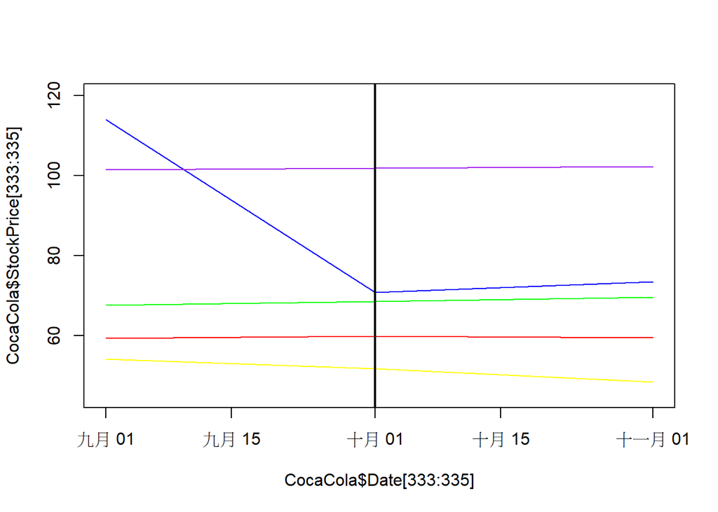

```r
plot(CocaCola$Date[333:335],CocaCola$StockPrice[333:335],type="l",col="red",ylim = c(45,120))
lines(ProcterGamble$Date[333:335],ProcterGamble$StockPrice[333:335],col="blue",lty=1,ylim = c(45,120))
lines(Boeing$Date[333:335],Boeing$StockPrice[333:335],col="yellow",lty=1,ylim = c(45,120))
lines(GE$Date[333:335],GE$StockPrice[333:335],col="green",lty=1,ylim = c(45,120))
lines(IBM$Date[333:335],IBM$StockPrice[333:335],col="purple",lty=1,ylim = c(45,120))
abline(v=as.Date(c("1997-10-01")),lwd=2)
```

```r
#blue=ProcterGamble
#yellow=Boeing
```

**§ 3.4** In the last two years of this time period (2004 and 2005) which stock seems to be performing the best, in terms of increasing stock price?

```r
which(CocaCola$Date=="1995-01-01")
```

```
[1] 301
```

```r
which(CocaCola$Date=="2005-12-01")
```

```
[1] 432
```

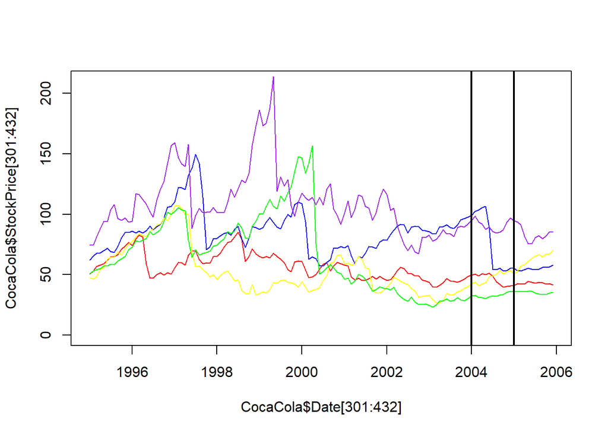

```r
plot(CocaCola$Date[301:432],CocaCola$StockPrice[301:432],type="l",col="red",ylim = c(0,210))
lines(ProcterGamble$Date[301:432],ProcterGamble$StockPrice[301:432],col="blue",lty=1,ylim = c(0,210))
lines(Boeing$Date[301:432],Boeing$StockPrice[301:432],col="yellow",lty=1,ylim = c(0,210))
lines(GE$Date[301:432],GE$StockPrice[301:432],col="green",lty=1,ylim = c(0,210))
lines(IBM$Date[301:432],IBM$StockPrice[301:432],col="purple",lty=1,ylim = c(0,210))
abline(v=as.Date(c("2004-01-01")),lwd=2)
abline(v=as.Date(c("2005-01-01")),lwd=2)
```

```r
#ans=Boieng
```

### Section-4 Monthly Trends

**§ 4.1** For IBM, compare the monthly averages to the overall average stock price. In which months has IBM historically had a higher stock price (on average)? Select all that apply.

```r
tapply(IBM$StockPrice,months(IBM$Date),mean)%>%sort
```

```
  十月 十一月   七月   九月   六月   八月 十二月   一月   五月   四月   三月   二月
 137.3  138.0  139.1  139.1  139.1  140.1  140.8  150.2  151.5  152.1  152.4  152.7
```

```r
mean(IBM$StockPrice)
```

```
[1] 144.4
```

```r
#January<May<April<March<February
```

February, March, April, May, January have higher stock price than average(144.4).

**§ 4.2** General Electric and Coca-Cola both have their highest average stock price in the same month. Which month is this?

```r
tapply(GE$StockPrice,months(GE$Date),mean) %>%sort
```

```
  October September      June    August      July  November  December       May   January
    56.24     56.24     56.47     56.50     56.73     57.29     59.10     60.87     62.05
 February     March     April
    62.52     63.15     64.48
```

```r
tapply(CocaCola$StockPrice,months(CocaCola$Date),mean) %>%sort
```

```
September   October    August      July  November  December   January  February      June
    57.60     57.94     58.88     58.98     59.10     59.73     60.37     60.73     60.81
      May     March     April
    61.44     62.07     62.69
```

```r
#April
```

General Electric and Coca-Cola both have their highest average stock price in April.

**§ 4.3** For the months of December and January, every company’s average stock is higher in one month and lower in the other. In which month are the stock prices lower?

```r
tapply(GE$StockPrice,months(GE$Date),mean) %>%sort
```

```
  October September      June    August      July  November  December       May   January
    56.24     56.24     56.47     56.50     56.73     57.29     59.10     60.87     62.05
 February     March     April
    62.52     63.15     64.48
```

The stock prices are lower in December.

```r
#sort做順序
# use 大於
```

**§ 4.2** General Electric and Coca-Cola both have their highest average stock price in the same month. Which month is this?

```r
tapply(GE$StockPrice,months(GE$Date),mean)%>%sort
```

```
  十月   九月   六月   八月   七月 十一月 十二月   五月   一月   二月   三月   四月
 56.24  56.24  56.47  56.50  56.73  57.29  59.10  60.87  62.05  62.52  63.15  64.48
```

```r
tapply(CocaCola$StockPrice,months(CocaCola$Date),mean)%>%sort
```

```
  九月   十月   八月   七月 十一月 十二月   一月   二月   六月   五月   三月   四月
 57.60  57.94  58.88  58.98  59.10  59.73  60.37  60.73  60.81  61.44  62.07  62.69
```

```r
#
#
```

**§ 4.3** For the months of December and January, every company’s average stock is higher in one month and lower in the other. In which month are the stock prices lower?

```r
tapply(GE$StockPrice,months(GE$Date),mean)%>%sort
```

```
  十月   九月   六月   八月   七月 十一月 十二月   五月   一月   二月   三月   四月
 56.24  56.24  56.47  56.50  56.73  57.29  59.10  60.87  62.05  62.52  63.15  64.48
```

```r
tapply(CocaCola$StockPrice,months(CocaCola$Date),mean)%>%sort
```

```
  九月   十月   八月   七月 十一月 十二月   一月   二月   六月   五月   三月   四月
 57.60  57.94  58.88  58.98  59.10  59.73  60.37  60.73  60.81  61.44  62.07  62.69
```

```r
tapply(IBM$StockPrice,months(IBM$Date),mean)%>%sort
```

```
  十月 十一月   七月   九月   六月   八月 十二月   一月   五月   四月   三月   二月
 137.3  138.0  139.1  139.1  139.1  140.1  140.8  150.2  151.5  152.1  152.4  152.7
```

```r
tapply(ProcterGamble$StockPrice,months(ProcterGamble$Date),mean)%>%sort
```

```
  九月   七月   十月   八月   三月   六月   四月   五月 十二月 十一月   二月   一月
 76.62  76.65  76.68  76.82  77.35  77.39  77.69  77.86  78.30  78.46  79.03  79.62
```

```r
tapply(Boeing$StockPrice,months(Boeing$Date),mean)%>%sort
```

```
十一月   十月 十二月   九月   一月   七月   八月   三月   二月   四月   六月   五月
 45.15  45.22  46.17  46.30  46.51  46.55  46.86  46.88  46.89  47.05  47.39  48.14
```

```r
#
#
```